# I use my phone too much

## Chronically Online

[figure not shown]

Graffiti like picture of a hand locked to a phone

An exploration into my phone usage throughout the day and the enjoyment I get out of it from a Google form I created and logged into a Google Spreadsheet

## Tiny fraction of my average screen time per app

I had a total of 50 observations of times I used my phone

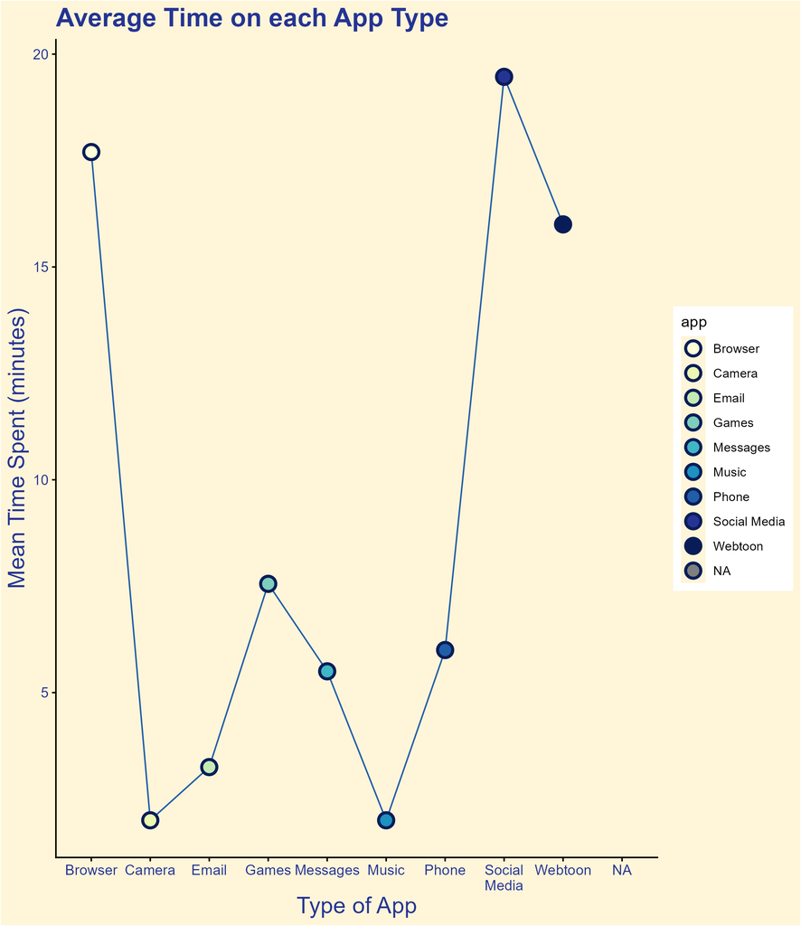

However, this is but a fraction of the time I spend on my phone due to forgetting to log data. I spent the most time on social media, my browser, and Webtoon which implies I primarily use my phone for entertainment, so, I’m not even being productive.

## Enjoyment I get from each app

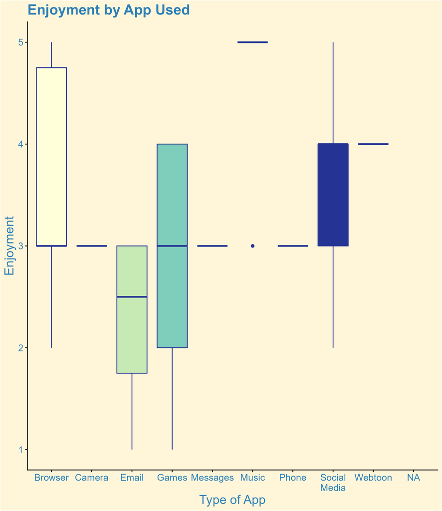

The enjoyment I get from using my phone varies from app to app and stays pretty consistent for apps that aren’t mean to be particularly emotion inducing like the camera app or my text messages. On the other hand, my enjoyment drops pretty low for things like checking my email or when playing games which is probably due to losing or receiving less than favourable news.

## My phone is a prison

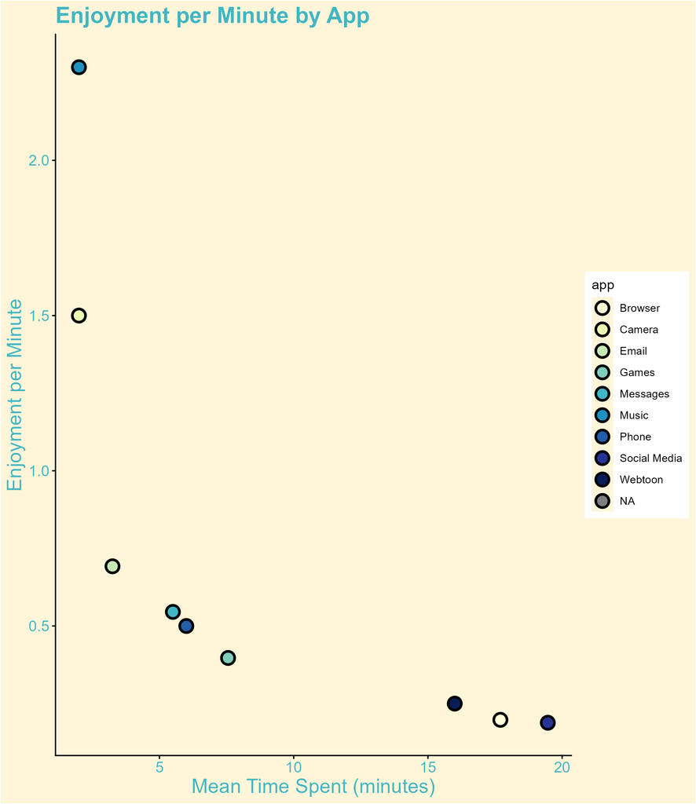

As you can see, the enjoyment to time spent ratio is abysmal. The longer I spend on my phone the less I enjoy it, so why do I continue? Music has the highest enjoyment to time ratio which makes sense, I play a playlist and then close my phone, the less time I spend on my phone the happier I should be.

## Go to bed

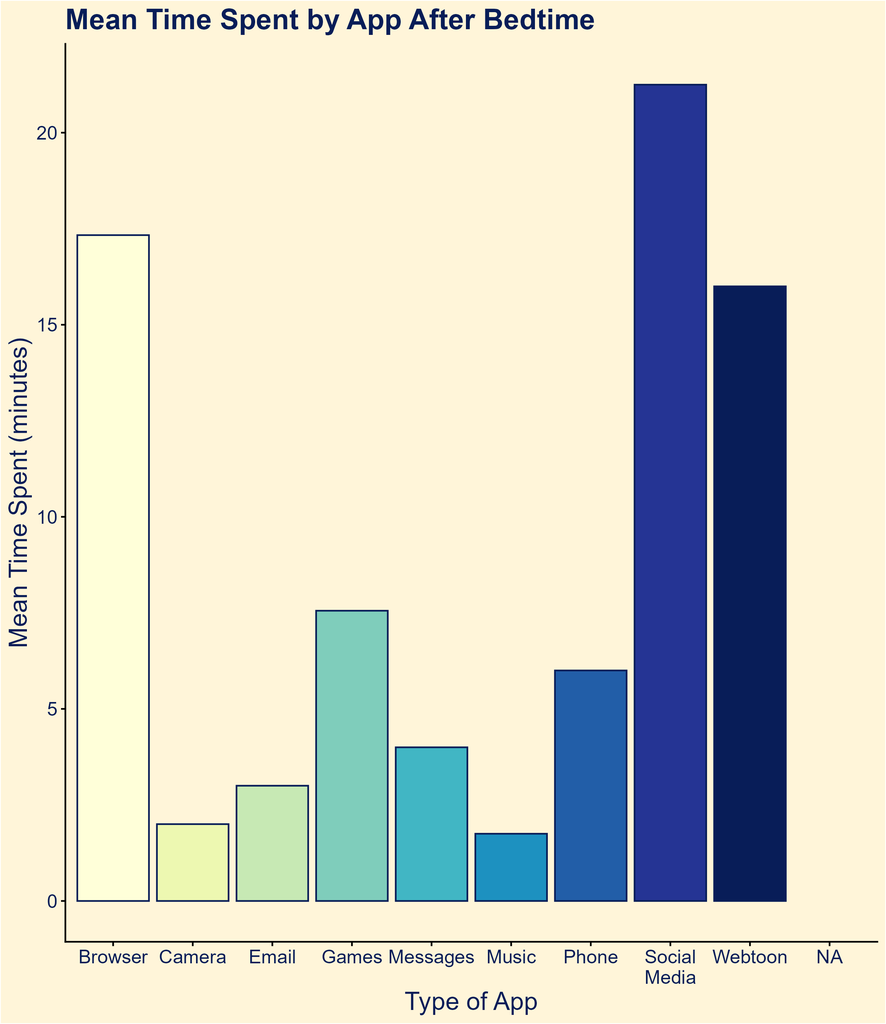

This shows the average time I spend on my phone after 10 pm. An ideal bedtime ranges from 8pm to 10pm and this is time I spend AFTER 10pm which is not good. My sleep schedule is very bad and I have no one else to blame but myself.

## In conclusion

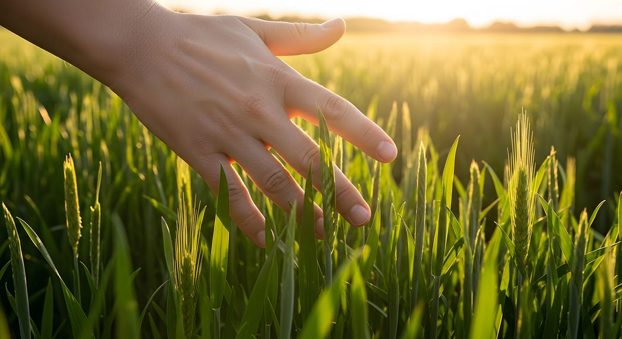

I need to put the phone down. But it’s too addicting. Ingrained in my daily actions.